## Visualizations

### Sunshine Hours - Exploratory Variable

These visualizations represent the hours of sunshine the cities of Iquitos and San Juan receive on average during the year. From our research, we found that mosquitos who carry the dengue infection reproduce and bite humans at a higher rate during times of high temperatures. We wanted to explore if the amount of sunshine duration during a particular time of the year had a correlation with the amount of cases there were in a specific month. We hypothesized that in Iquitos, the months of July, August and September would have the most number of cases since these months had a higher amount of sunshine hours on average. For San Juan, we predicted the months of March, April, June, July, August, and September would have the most number of cases which in turn would lead to this city having more cases of dengue fever than Iquitos.

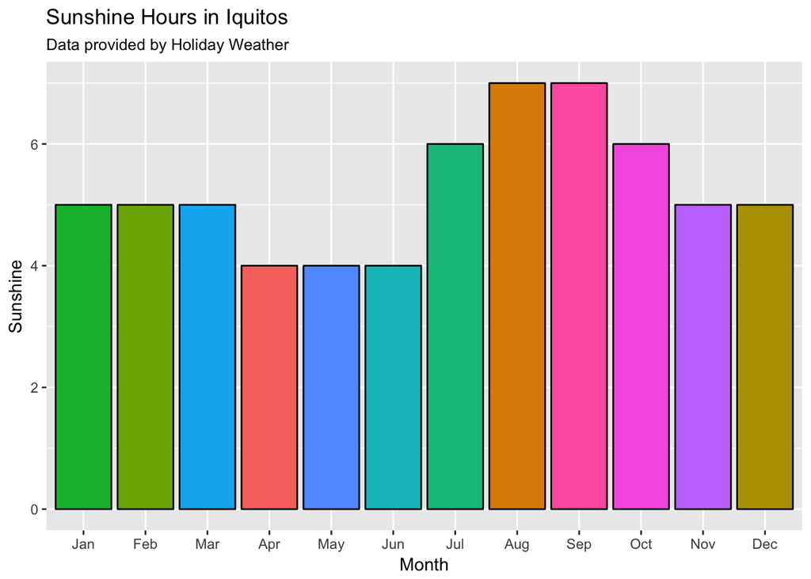

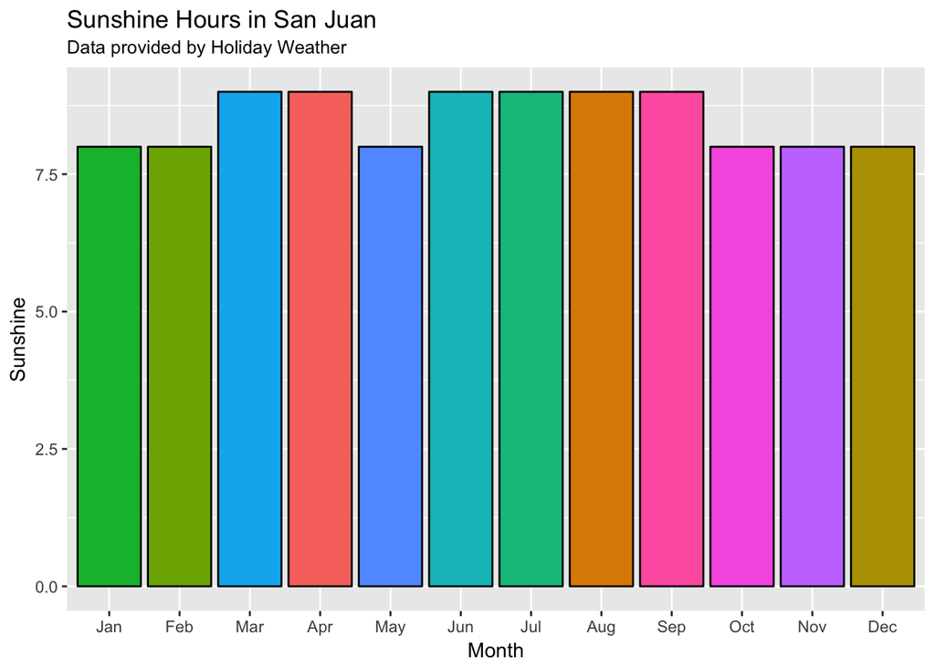